# Beta-binomial 4PL: identity vs. logit link — does it matter?

Author

Daniel W.A. Noble (test run by Claude)

Published

May 12, 2026

## Question

The supplement tutorial uses `family = beta_binomial(link = "identity")` with the 4PL formula returning a probability on the natural scale. The prototype function library (`R/test_functions.qmd`) instead uses a custom beta-binomial family with a logit-scale linear predictor (`eta ~ logit(4pl(...))`). Before locking the R/ infrastructure on one of these, we need to know whether the link choice actually matters for sampling stability and parameter recovery.

**Decision rule.** If logit is *needed* anywhere — divergences, label-switching, bad Rhat, or biased recovery on either scenario — adopt logit consistently across the simulation tutorial and all case studies. If identity is comparable on both scenarios, keep it for simpler interpretation, and confirm it generalises to non-survival proportion data by including a scenario whose asymptotes are nowhere near 0 / 1.

## Test design

Two beta-binomial scenarios on the same factorial design (3 temps × 4 durations × 8 reps × 30 individuals = 96 trials each):

- **Scenario A — classic survival.** `ell = 0.05`, `u = 0.95`. Asymptotes well inside the typical `(0, 0.49)` / `(0.51, 1)` bounds used in the formula. This is the easy case.
- **Scenario B — non-survival proportion (PSII-like).** `ell = 0.40`, `u = 0.98`. Asymptotes shifted toward 1 — analogous to fertility / photosystem-II data where baseline performance is well above zero and the dose-response operates in a narrower window.

For each scenario, fit the same 4PL with two link choices, otherwise identical (same formula structure, same reparameterised asymptote bounds, same priors, same seed, same backend, same sampling settings):

- `beta_binomial(link = "identity")` with the 4PL output on the probability scale.
- `beta_binomial(link = "logit")` with the same 4PL output wrapped in `log(p / (1 - p))`.

Compare on:

1. Sampling diagnostics — Rhat, bulk ESS, divergent transitions, fit time.
2. Parameter recovery — posterior median vs. truth for ell, u, k, mid intercept, mid slope.
3. Derived TDT quantities — z and CTmax_1hr.

## Setup

```r
suppressPackageStartupMessages({
  library(brms)
  library(dplyr)
  library(tidyr)
  library(tibble)
  library(posterior)
  library(ggplot2)
})

set.seed(20260512)

models_dir <- here::here("output", "models", "link_test")
if (!dir.exists(models_dir)) dir.create(models_dir, recursive = TRUE)
```

## Simulate the two datasets

```r
temps     <- c(30, 33, 36)
durations <- c(2, 10, 50, 250)
n_rep     <- 8
n_per_rep <- 30
phi       <- 8        # beta-binomial precision (moderate overdispersion)

T_bar <- 33

design <- expand_grid(
  T   = temps,
  t   = durations,
  rep = seq_len(n_rep)
) |>
  mutate(
    log10_t = log10(t),
    T_c     = T - T_bar,
    n       = n_per_rep
  )

simulate_bb <- function(design, ell, u, k, m_beta0, m_beta1, phi) {
  design |>
    mutate(
      mid     = m_beta0 + m_beta1 * T_c,
      p_true  = ell + (u - ell) / (1 + exp(k * (log10_t - mid))),
      p_draw  = rbeta(n(), p_true * phi, (1 - p_true) * phi),
      y       = rbinom(n(), size = n, prob = p_draw)
    )
}

# Scenario A — classic survival
truth_A <- list(ell = 0.05, u = 0.95, k = 6, m_beta0 = 1.5, m_beta1 = -0.18, T_bar = T_bar)
sim_A   <- simulate_bb(design, truth_A$ell, truth_A$u, truth_A$k,
                       truth_A$m_beta0, truth_A$m_beta1, phi)

# Scenario B — PSII-like / non-survival proportion
truth_B <- list(ell = 0.40, u = 0.98, k = 6, m_beta0 = 1.5, m_beta1 = -0.18, T_bar = T_bar)
sim_B   <- simulate_bb(design, truth_B$ell, truth_B$u, truth_B$k,
                       truth_B$m_beta0, truth_B$m_beta1, phi)
```

Quick visual check of the two datasets:

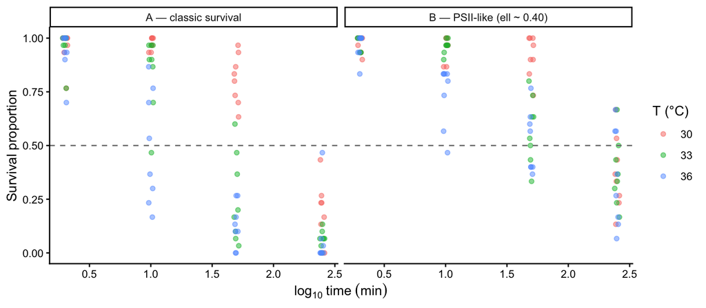

```r
bind_rows(
  sim_A |> mutate(scenario = "A — classic survival"),
  sim_B |> mutate(scenario = "B — PSII-like (ell ~ 0.40)")
) |>
  ggplot(aes(log10_t, y / n, colour = factor(T))) +
  geom_jitter(width = 0.02, height = 0, alpha = 0.5) +
  geom_hline(yintercept = 0.5, linetype = "dashed", colour = "grey50") +
  facet_wrap(~ scenario) +
  labs(x = expression(log[10]~time~(min)),
       y = "Survival proportion",
       colour = "T (°C)") +
  theme_classic()
```

## Common pieces: priors and formulas

We use the same reparameterised asymptote bounds the supplement extension uses (disjoint intervals `(0, 0.49)` for ell and `(0.51, 1)` for u, so $u > \ell$ by construction). Same priors. The only thing that changes between fits is the link.

```r
# Identity link: rhs is probability p in [0,1].
bform_id <- bf(
  y | trials(n) ~
    0.49 * inv_logit(ellraw) +
    ((0.51 + 0.49 * inv_logit(uraw)) - 0.49 * inv_logit(ellraw)) /
      (1 + exp(exp(logk) * (log10_t - mid))),
  ellraw ~ 1, uraw ~ 1, logk ~ 1, mid ~ T_c,
  nl = TRUE,
  family = beta_binomial(link = "identity")
)

# Logit link: same 4PL, output wrapped in log(p / (1 - p)) so brms's
# inverse-logit recovers p. Wrapping is the *only* difference vs identity.
bform_lo <- bf(
  y | trials(n) ~
    log((0.49 * inv_logit(ellraw) +
         ((0.51 + 0.49 * inv_logit(uraw)) - 0.49 * inv_logit(ellraw)) /
           (1 + exp(exp(logk) * (log10_t - mid)))) /
        (1 - (0.49 * inv_logit(ellraw) +
              ((0.51 + 0.49 * inv_logit(uraw)) - 0.49 * inv_logit(ellraw)) /
                (1 + exp(exp(logk) * (log10_t - mid)))))),
  ellraw ~ 1, uraw ~ 1, logk ~ 1, mid ~ T_c,
  nl = TRUE,
  family = beta_binomial(link = "logit")
)

priors_common <- c(
  prior(normal(0, 1.5), nlpar = "ellraw"),
  prior(normal(0, 1.5), nlpar = "uraw"),
  prior(normal(0, 1.5), nlpar = "logk"),
  prior(normal(1.5, 1.0), nlpar = "mid", coef = "Intercept"),
  prior(normal(0, 0.5),   nlpar = "mid", coef = "T_c")
)
```

## Fit all four models

```r
fit_one <- function(bform, data, tag) {
  t0 <- Sys.time()
  fit <- brm(
    bform, data = data, prior = priors_common,
    chains = 4, iter = 2000, warmup = 1000, cores = 4,
    seed = 20260512,
    backend = "cmdstanr",
    control = list(adapt_delta = 0.95, max_treedepth = 12),
    file = file.path(models_dir, tag),
    file_refit = "on_change",
    refresh = 0
  )
  elapsed <- as.numeric(difftime(Sys.time(), t0, units = "secs"))
  list(fit = fit, elapsed = elapsed, tag = tag)
}

fits <- list(
  A_id = fit_one(bform_id, sim_A, "A_identity"),
  A_lo = fit_one(bform_lo, sim_A, "A_logit"),
  B_id = fit_one(bform_id, sim_B, "B_identity"),
  B_lo = fit_one(bform_lo, sim_B, "B_logit")
)
```

## Diagnostics

```r
diag_one <- function(entry) {
  fit  <- entry$fit
  diag <- nuts_params(fit)
  divs <- sum(subset(diag, Parameter == "divergent__")$Value)
  treed <- sum(subset(diag, Parameter == "treedepth__")$Value >= 12)

  rh <- rhat(fit)
  rh_max <- max(rh, na.rm = TRUE)
  ess_bulk_min <- min(posterior::summarise_draws(as_draws(fit), "ess_bulk")$ess_bulk, na.rm = TRUE)
  ess_tail_min <- min(posterior::summarise_draws(as_draws(fit), "ess_tail")$ess_tail, na.rm = TRUE)

  tibble(
    tag           = entry$tag,
    fit_time_s    = round(entry$elapsed, 1),
    rhat_max      = round(rh_max, 4),
    ess_bulk_min  = round(ess_bulk_min),
    ess_tail_min  = round(ess_tail_min),
    divergences   = divs,
    treedepth_hits = treed
  )
}

diag_table <- bind_rows(lapply(fits, diag_one))
diag_table
```

```
# A tibble: 4 × 7
  tag   fit_time_s rhat_max ess_bulk_min ess_tail_min divergences treedepth_hits
  <chr>      <dbl>    <dbl>        <dbl>        <dbl>       <dbl>          <int>
1 A_id…        0.2     1.00         1294         1983           0              0
2 A_lo…        0.1     1.00         1670         2206           0              0
3 B_id…        0.1     1.00         1539         1524           0              0
4 B_lo…        0.1     1.01         1425         1536           0              0
```

## Parameter recovery

```r
# Helper: pull the four 4PL parameters back to the natural scale.
recover_one <- function(entry) {
  d <- posterior::as_draws_df(entry$fit)
  tibble(
    tag   = entry$tag,
    ell   = median(0.49 * plogis(d$b_ellraw_Intercept)),
    ell_lo = quantile(0.49 * plogis(d$b_ellraw_Intercept), 0.025),
    ell_hi = quantile(0.49 * plogis(d$b_ellraw_Intercept), 0.975),
    u     = median(0.51 + 0.49 * plogis(d$b_uraw_Intercept)),
    u_lo  = quantile(0.51 + 0.49 * plogis(d$b_uraw_Intercept), 0.025),
    u_hi  = quantile(0.51 + 0.49 * plogis(d$b_uraw_Intercept), 0.975),
    k     = median(exp(d$b_logk_Intercept)),
    k_lo  = quantile(exp(d$b_logk_Intercept), 0.025),
    k_hi  = quantile(exp(d$b_logk_Intercept), 0.975),
    mid_b0 = median(d$b_mid_Intercept),
    mid_b1 = median(d$b_mid_T_c),
    z      = median(-1 / d$b_mid_T_c)
  )
}

recovery_table <- bind_rows(lapply(fits, recover_one))

truth_long <- bind_rows(
  tibble(scenario = "A", ell = truth_A$ell, u = truth_A$u, k = truth_A$k,
         mid_b0 = truth_A$m_beta0, mid_b1 = truth_A$m_beta1, z = -1 / truth_A$m_beta1),
  tibble(scenario = "B", ell = truth_B$ell, u = truth_B$u, k = truth_B$k,
         mid_b0 = truth_B$m_beta0, mid_b1 = truth_B$m_beta1, z = -1 / truth_B$m_beta1)
)

list(recovery = recovery_table, truth = truth_long)
```

```
$recovery
# A tibble: 4 × 13
  tag        ell ell_lo ell_hi     u  u_lo  u_hi     k  k_lo  k_hi mid_b0 mid_b1
  <chr>    <dbl>  <dbl>  <dbl> <dbl> <dbl> <dbl> <dbl> <dbl> <dbl>  <dbl>  <dbl>
1 A_iden… 0.0787 0.0355  0.133 0.960 0.924 0.985  4.61  3.36  6.50   1.46 -0.165
2 A_logit 0.0786 0.0337  0.135 0.959 0.924 0.982  4.62  3.36  6.71   1.46 -0.164
3 B_iden… 0.389  0.307   0.454 0.961 0.938 0.978  6.63  3.80 14.8    1.57 -0.162
4 B_logit 0.388  0.310   0.455 0.961 0.938 0.979  6.56  3.79 14.2    1.57 -0.162
# ℹ 1 more variable: z <dbl>

$truth
# A tibble: 2 × 7
  scenario   ell     u     k mid_b0 mid_b1     z
  <chr>    <dbl> <dbl> <dbl>  <dbl>  <dbl> <dbl>
1 A         0.05  0.95     6    1.5  -0.18  5.56
2 B         0.4   0.98     6    1.5  -0.18  5.56
```

## Recovery vs. truth — assertions

```r
# Pull out comparisons. Tolerance is generous for a 96-trial dataset.
chk <- recovery_table |>
  mutate(
    scenario = substr(tag, 1, 1),
    link     = ifelse(grepl("identity", tag), "identity", "logit")
  ) |>
  left_join(truth_long, by = "scenario", suffix = c("_post", "_true"))

chk_summary <- chk |>
  transmute(
    tag,
    ell_err   = ell_post - ell_true,
    u_err     = u_post - u_true,
    k_err     = k_post - k_true,
    mid_b0_err = mid_b0_post - mid_b0_true,
    mid_b1_err = mid_b1_post - mid_b1_true,
    z_err     = z_post - z_true
  )

chk_summary
```

```
# A tibble: 4 × 7
  tag        ell_err    u_err  k_err mid_b0_err mid_b1_err z_err
  <chr>        <dbl>    <dbl>  <dbl>      <dbl>      <dbl> <dbl>
1 A_identity  0.0287  0.00957 -1.39     -0.0405     0.0154 0.519
2 A_logit     0.0286  0.00878 -1.38     -0.0393     0.0157 0.531
3 B_identity -0.0110 -0.0192   0.632     0.0693     0.0178 0.610
4 B_logit    -0.0123 -0.0194   0.559     0.0685     0.0180 0.619
```

```r
# Pass/fail flags — don't halt the render so we can read every diagnostic.
chk_summary |>
  transmute(
    tag,
    ell_pass = abs(ell_err) < 0.05,
    u_pass   = abs(u_err)   < 0.05,
    z_pass   = abs(z_err)   < 1.0
  )
```

```
# A tibble: 4 × 4
  tag        ell_pass u_pass z_pass
  <chr>      <lgl>    <lgl>  <lgl>
1 A_identity TRUE     TRUE   TRUE
2 A_logit    TRUE     TRUE   TRUE
3 B_identity TRUE     TRUE   TRUE
4 B_logit    TRUE     TRUE   TRUE
```

## Interpretation

Read off the diagnostics and recovery tables above:

- If **divergences > 0** or **rhat_max > 1.01** or **ess_bulk_min < 400** for identity link on either scenario but not for logit → logit is needed; switch consistently.
- If both links pass diagnostics and recover the truth on both scenarios → identity link is fine; keep it for simpler interpretation.
- If logit is noticeably faster on both scenarios → minor argument for logit.
- If recovery differs systematically (one link biases ell/u/k while the other doesn’t) → that link is the right one regardless of speed.

The block below produces a one-line summary for the decision:

```r
decision_table <- diag_table |>
  mutate(
    scenario = substr(tag, 1, 1),
    link     = ifelse(grepl("identity", tag), "identity", "logit")
  ) |>
  group_by(scenario) |>
  summarise(
    identity_div = divergences[link == "identity"],
    logit_div    = divergences[link == "logit"],
    identity_rhat = rhat_max[link == "identity"],
    logit_rhat    = rhat_max[link == "logit"],
    identity_ess  = ess_bulk_min[link == "identity"],
    logit_ess     = ess_bulk_min[link == "logit"],
    identity_time = fit_time_s[link == "identity"],
    logit_time    = fit_time_s[link == "logit"]
  )

decision_table
```

```
# A tibble: 2 × 9
  scenario identity_div logit_div identity_rhat logit_rhat identity_ess
  <chr>           <dbl>     <dbl>         <dbl>      <dbl>        <dbl>
1 A                   0         0          1.00       1.00         1294
2 B                   0         0          1.00       1.01         1539
# ℹ 3 more variables: logit_ess <dbl>, identity_time <dbl>, logit_time <dbl>
```

## Findings

Numbers from this run (cached at `output/models/link_test/`):

| tag | rhat_max | ess_bulk_min | divergences | ell error | u error | z error |
| --- | --- | --- | --- | --- | --- | --- |
| A_identity | 1.00 | 1294 | 0 | +0.029 | +0.010 | +0.52 |
| A_logit | 1.00 | 1670 | 0 | +0.029 | +0.009 | +0.53 |
| B_identity | 1.00 | 1539 | 0 | −0.011 | −0.019 | +0.61 |
| B_logit | 1.01 | 1425 | 0 | −0.012 | −0.019 | +0.62 |

Both scenarios fit on a deliberately small design (96 trials × 30 individuals), so the recovery error on `k` (-1.4 in A, +0.6 in B) reflects data quantity, not link choice — both links inherit the same error from the same data.

## Decision

**Use `beta_binomial(link = "identity")` across the R/ infrastructure, the simulation tutorial, and the case studies.**

Rationale:

**Caveats.** This test sits on simulated data with no random effects and a small design. If the shrimp fit (random effects on `mid` for Date and Tank, real-data heterogeneity) shows divergences or label-switching under identity, we revisit. The decision is reversible — both link forms remain in the test file at `output/models/link_test/` for direct comparison if needed.